# Project M1

Andreas, Simon, Jess, Lars

14/9/2019

# SparNord ATM transactions

In this project we would work around the following problem statement. To solve the statement we will use the ML-techniques which the course so far have presented for us.

> Predict whether the transaction in the Spar Nord ATMs is a euro transaction or not.

In order to answer our problem statement, we’ve obtained a data set published by Spar Nord A/S. The data set contains data of all cash withdrawals made at their ATMs in Denmark in 2017. Based on the data set, we then want to set up a model which can ‘predict’ whether the transaction in the ATMs is in euros or not.

Source: https://sparnordopenbanking.com/OpenData.

The raw-dataset contains 2.5 million observations with 33 variables, which range from information about day, time and month to weather conditions, coordinates and cardtype. Some of the variables include NA, but those are primarily message codes and text related to the withdrawal (some kind of error). This mean the dataset are pretty complete and there are no need for data imputation or cleaning. The next step is to modify the data to our problem statement, which is descried in feature generation. Before we get to that section, we will present a visually overview of the raw-data with summary statistics and explanatory comments.

```r
library(tidyverse)
library(ggforce)
library(caret)
library(yardstick)
library(knitr)
library(ggthemes)
library(ggridges)
library(kableExtra)
library(gridExtra)
library(VIM)
library(ggridges)
library(ggmap)
library(osmdata)
library(sf)
library(GGally)
library(FactoMineR)
library(geosphere)
library(sf)
#library(Hmisc)

base <- "#1f83b4"
base2 <- "#12a2a8"

load(file="generated_data/sATM.Rdata")
load(file="generated_data/bATM.Rdata")
load(file="generated_data/fdata.Rdata")

set.seed(20092019)
```

## Data

One of the most common errors in data science is not looking at the data, so we will start with this. The dataset includes 113 different ATM’s from SparNord placed around Denmark. Each include coordinates, which will be usefull later for feature generation, but we can use these to plot the machines in a map.

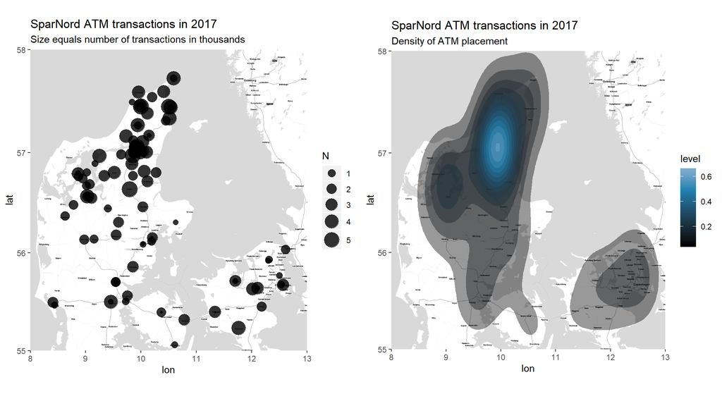

```r
coord <- as.matrix(data.frame(min = c(8, 55),
                              max = c(13, 58),
                              row.names = c("x","y")))

s <- bATM %>% filter(atm_lat > coord[2,1] & atm_lat < coord[2,2] &
                     atm_lon < coord[1,2] & atm_lon > coord[1,1]) %>%
  group_by(atm_id) %>%
  summarize(n   = n(),
            lat = first(atm_lat),
            lon = first(atm_lon),
            man = first(atm_manufacturer))


# First map ---------------------------------------------------------------
map9  <- get_stamenmap(coord, zoom = 9,  maptype = "toner-lite", force = TRUE)

p1 <- ggmap(map9) +
  geom_point(data = s, aes(lon,lat, size=n/1000), alpha = 0.8) +
  scale_size(range = c(0.5, 8)) +
  labs(title="SparNord ATM transactions in 2017",
       subtitle = "Size equals number of transactions in thousands", size="N")

p2 <- ggmap(map9) +
  stat_density_2d(data = s, aes(lon,lat, fill = ..level..), geom = "polygon", alpha = .4) +
  #scale_fill_viridis_c(option = "magma") +
  scale_fill_gradient2(midpoint=0.5,low = "black", mid = base, high = "white") +
  labs(title="SparNord ATM transactions in 2017",
       subtitle = "Density of ATM placement")

grid.arrange(p1,p2, nrow=1)
```

Quick summary of transactions by region

```r
fdata %>% group_by(Region) %>% summarise(N=n()) %>% t() %>% kable() %>% kable_styling("condensed")
```

| Region | Region Hovedstaden | Region Midtjylland | Region Nordjylland | Region Sjælland | Region Syddanmark |
| --- | --- | --- | --- | --- | --- |
| N | 76925 | 391462 | 1610445 | 197181 | 192559 |

In this first visualisation we see that the activity is based heavily around Nordjylland, which is not surprising if you know the bank. We also see that there is a substantial difference in the number of transactions at each machine.

Well, lets see how the transactions are distributed in time:

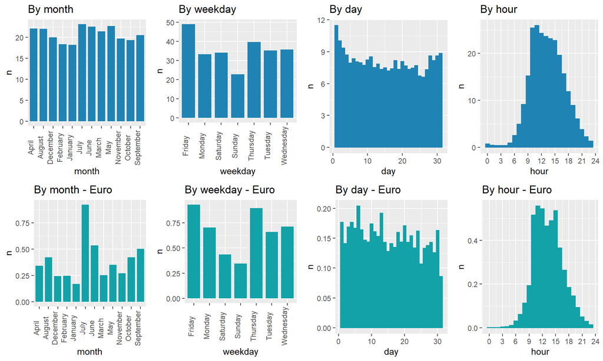

```r
s1 <- bATM %>% group_by(month) %>% summarize(n=n()/1000) %>%
  ggplot(aes(month,n))   + geom_col(fill=base, width=0.8)     +
  labs(title = "By month") +
  theme(axis.text.x = element_text(angle = 90, vjust=-0.1))

s2 <- bATM %>% group_by(day) %>% summarize(n=n()/1000) %>%
  ggplot(aes(day,n)) + geom_col(fill=base, color=base)         +
  labs(title = "By day")

s3 <- bATM %>% group_by(weekday) %>% summarize(n=n()/1000) %>%
  ggplot(aes(weekday,n)) + geom_col(fill=base, width=0.8) +
  labs(title = "By weekday") +
  theme(axis.text.x = element_text(angle = 90, vjust=-0.1))

s4 <- bATM %>% group_by(hour) %>% summarize(n=n()/1000) %>%
  ggplot(aes(hour,n))    + geom_col(fill=base, color=base)       +
  labs(title = "By hour") +
  scale_x_continuous(breaks=c(0,3,6,9,12,15,18,21,24))



#Ovenstående plots illustrerer fordelingen af alle transaktioner på hhv. de forskellige måneder, ugedage, dage på måneden og timer.

#The first 4 plots shows the amount of withdraws destributed on weekday, month, day and hour. We can see a pattern in the plots, where there is about 20.000 withdraws each month, except from the summer months 'May','June' and'July' where there is about 25.000 withdraws. This could be explained by the fact that people are more likely to take on vacation in these months. Further it can be seen that people are more likely to make a withdraw in the beginning of the month, where we can see that amount of withdraws is highest on the 1st of the month, and right before the weekend, where friday is the day with the highest amount of withdraws.

s5 <- bATM %>% filter(currency == "EUR") %>% group_by(weekday) %>% summarize(n=n()/1000) %>% ggplot(aes(weekday,n)) + geom_col(fill=base2, width=0.8)  + labs(title="By weekday - Euro")+
  theme(axis.text.x = element_text(angle = 90, vjust=-0.1))
s6 <- bATM %>% filter(currency == "EUR") %>% group_by(month) %>% summarize(n=n()/1000) %>% ggplot(aes(month,n)) + geom_col(fill=base2, width=0.8)  + labs(title="By month - Euro")+
  theme(axis.text.x = element_text(angle = 90, vjust=-0.1))
s7 <- bATM %>% filter(currency == "EUR") %>% group_by(day) %>% summarize(n=n()/1000) %>% ggplot(aes(day,n)) + geom_col(color = base2, fill = base2) +
labs(title="By day - Euro")
s8 <- bATM %>% filter(currency == "EUR") %>% group_by(hour) %>% summarize(n=n()/1000) %>% ggplot(aes(hour,n)) + geom_col(color = base2, fill = base2) + labs(title="By hour - Euro") +
  scale_x_continuous(breaks=c(0,3,6,9,12,15,18,21,24))

#The plots shows the amount of the euro-transactions destributed on weekday, month, day and hour. We can see from the euro-month plot that people are more likely to withdraw euros in the summermonth July. This may be due to more people are going on vacations in the holiday-months like july. And like the case before we can see that people is slightly more likely to withdraw euros in the days leading up to the weekend and in the beginning of the months.

grid.arrange(s1,s3,s2,s4,s6,s5,s7,s8, nrow=2)
```

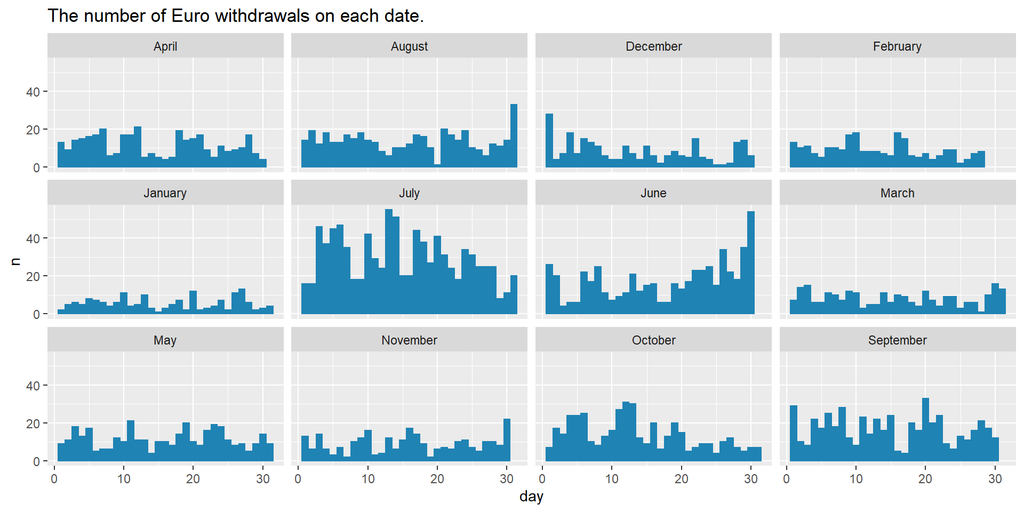

```r
bATM %>% filter(currency =="EUR") %>% group_by(day, month) %>% summarize(n=n()) %>% ggplot(aes(day, n)) + geom_col(fill=base, color=base) + facet_wrap(~month)  + labs(title="The number of Euro withdrawals on each date.")
```

```r
#The plots shows the amount of euro-withdraws on the specific day in the month. As can be seen from the plot the amount of euro-withdraws increases from the end of june to the end of july Which can be explained by the fact that people are going on vacation and the currency in that country is euro. It seems like people are more likely to withdraw euro in the holiday period.
```